# R Notebook- Discussion 1 - Biostatistics

For this analysis, we shall focus on measure of mental status, including the digit symbol substitution test (DSST – a test of attention) and the modified mini mental status exam (MMMSE). We are interested in determining correlates of decreased cognitive function.

The data to be analyzed for this assignment is a subset of the thousands of variables on a subset of the thousands of participants in this study. The questions to be addressed are:

What associations exist between measurements of cognitive function (DSST and MMMSE) and the available data on participant demographics (age, sex, weight, height), behavior (smoking, alcohol consumption), and various clinical and laboratory measures of organ system functioning (e.g, blood pressure, liver function, kidney function, lung function)?

What associations exist between the cognitive function measurements and mortality?

Are any of the cognitive function scores predictive of mortality beyond the predictive capabilities of the other available variables?

Do the cognitive function measures reflect underlying risk factors for death separate from other known disease processes (such as cardiovascular disease, kidney disease, diabetes, high blood pressure), or are these scores merely signs of those disease processes?

Demographics - - 65 or older - Generally healthy - Observational and cohort - longitidtal (11 years) - Exploratory analysis

```r
data <-read.csv("data/dsst.txt", sep="")#read in data
summary(data$dsst)
```

```
   Min. 1st Qu.  Median    Mean 3rd Qu.    Max.    NA's
   0.00   30.00   40.00   39.36   49.00   87.00     118
```

```r
#summarizedsst
summary(data$mmmse)
```

```
   Min. 1st Qu.  Median    Mean 3rd Qu.    Max.    NA's
   0.00   88.00   93.00   90.76   97.00  100.00      11
```

```r
summary(data$age)
```

```
   Min. 1st Qu.  Median    Mean 3rd Qu.    Max.
  65.00   71.00   74.00   75.12   78.00   97.00
```

```r
table(data$male)#number of males (0=female, 1=male)
```

```
   0    1
2133 1527
```

# We do descriptive statics to ensure data is coded accoring to the obhectves of the study, missimg data, assess assumptions on analysis (about variances, way to results about the ana;ysid ( results ),

What are correlates of decreased cognitive function? What associations exist between measurements of cognitivefunction and the available data onIparticipant demographics?Ibehavior?Iand various clinical and laboratory measures of organ systemfunctioning?

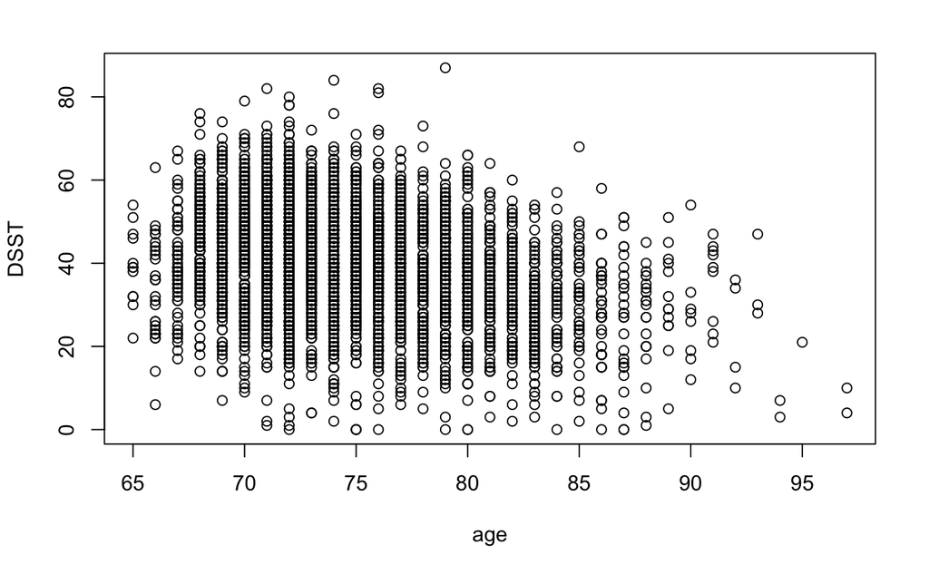

```r
#scatterplot
plot(data$age,data$dsst,xlab="age",ylab="DSST")
```

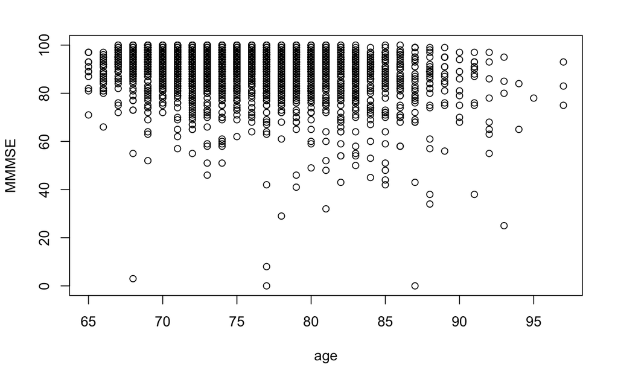

```r
plot(data$age,data$mmmse,xlab="age",ylab="MMMSE")
```

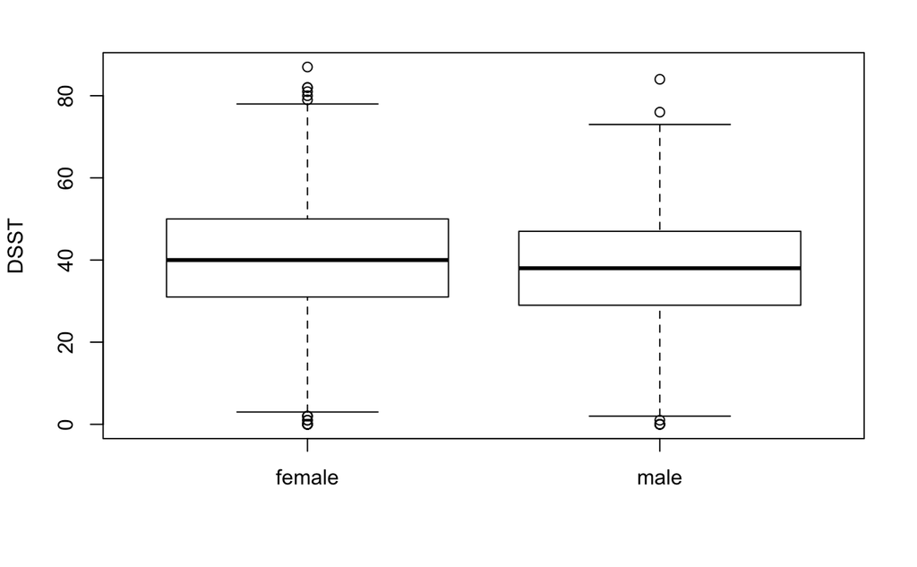

```r
#boxplots
boxplot(data$dsst~data$male,names=c("female","male"),ylab="DSST")
```

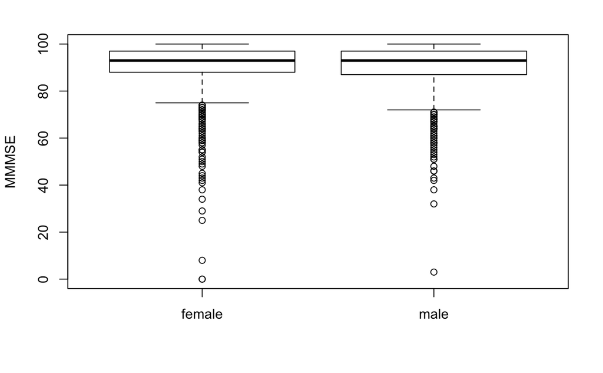

```r
boxplot(data$mmmse~data$male,names=c("female","male"),ylab="MMMSE")
```

# summarize your finding

```r
mod1 <-lm(dsst~age, data=data)
summary(mod1)
```

```
Call:
lm(formula = dsst ~ age, data = data)

Residuals:
    Min      1Q  Median      3Q     Max
-41.829  -8.513   0.171   8.676  50.992

Coefficients:
             Estimate Std. Error t value Pr(>|t|)
(Intercept) 101.70753    3.19394   31.84   <2e-16 ***
age          -0.83164    0.04251  -19.56   <2e-16 ***
---
Signif. codes:  0 ‘***’ 0.001 ‘**’ 0.01 ‘*’ 0.05 ‘.’ 0.1 ‘ ’ 1

Residual standard error: 12.92 on 3540 degrees of freedom
  (118 observations deleted due to missingness)
Multiple R-squared:  0.09757,   Adjusted R-squared:  0.09732
F-statistic: 382.8 on 1 and 3540 DF,  p-value: < 2.2e-16
```

# states if null hypothesus is true ,

# inrercepr - age=0, not meaningful

# we are missing the CI

```r
confint.default(mod1)
```

```
                 2.5 %      97.5 %
(Intercept) 95.4475149 107.9675480
age         -0.9149551  -0.7483263
```

# lets plot the regresson line

```r
#plots regression line on top of scatter plot
plot(data$age, data$dsst, xlab="Age", ylab="DSST")
abline(mod1, lwd=3, col="red")
legend("topright",c("Regression Line"),lwd=3, col="red", cex=0.8)
```

[output not shown]

# summarize your finding

We estimate that for each 1 year difference in age between two populations the mean DSST is 0.83 lower in the older group. The 95% confidence interval suggests that observed mean DSST scores between -0.75 and -0.91 lower per year are not unusual. We found the relationship between age and DSST score to be significant, with a p-valueless than 0.001.

# Do the same for gender (binary predictor)

```r
mod2 <-lm(dsst~male,data=data)
summary(mod2)
```

```
Call:
lm(formula = dsst ~ male, data = data)

Residuals:
    Min      1Q  Median      3Q     Max
-40.555  -9.555   0.300   9.445  46.445

Coefficients:
            Estimate Std. Error t value Pr(>|t|)
(Intercept)  40.5554     0.2976 136.262  < 2e-16 ***
male         -2.8554     0.4609  -6.195 6.49e-10 ***
---
Signif. codes:  0 ‘***’ 0.001 ‘**’ 0.01 ‘*’ 0.05 ‘.’ 0.1 ‘ ’ 1

Residual standard error: 13.52 on 3540 degrees of freedom
  (118 observations deleted due to missingness)
Multiple R-squared:  0.01073,   Adjusted R-squared:  0.01045
F-statistic: 38.38 on 1 and 3540 DF,  p-value: 6.489e-10
```

# we can do a t-test instead

```r
t.test(data$dsst[data$male==1],data$dsst[data$male==0])
```

```
    Welch Two Sample t-test

data:  data$dsst[data$male == 1] and data$dsst[data$male == 0]
t = -6.2226, df = 3228.8, p-value = 5.519e-10
alternative hypothesis: true difference in means is not equal to 0
95 percent confidence interval:
 -3.755090 -1.955671
sample estimates:
mean of x mean of y
 37.70007  40.55545
```

# use the DF, p-value, and the CI in your writeup